# R HW 03

Author

Robsen Gelalcha

Published

September 14, 2026

```r
library(tidyverse)
library(viridis)
library(ggridges)
```

# Exercise 1

The data was collected by the American National Election Studies. The data collection for the study began in August 2020 and continued until November 2020. A sample of US eligible voters were surveyed. The sample was randomly assigned to one of three groups: web only, mixed web and phone, and mixed video.

# Exercise 2

```r
anes <- read_csv("data/anes2020_subset.csv")
glimpse(anes)
```

```
Rows: 8,280
Columns: 6
$ CASEID     <dbl> 200015, 200022, 200039, 200046, 200053, 200060, 200084, 200…
$ hunt_fish  <dbl> 1, 0, 0, 0, 1, 0, 1, 0, 0, 1, 0, 1, 0, 0, 0, 1, 0, 0, 0, 0,…
$ scientists <dbl> 100, 70, 100, 85, 60, 85, 85, NA, 60, 50, 85, 100, 70, 70, …
$ education  <dbl> 6, 3, 2, 4, 8, 3, 4, 2, 2, 4, 2, 2, 2, 7, 3, 3, 6, 6, 6, 2,…
$ ideology   <dbl> 6, 4, 2, 3, 5, 4, 4, NA, NA, NA, NA, 4, 6, 3, 4, 6, 3, 3, 2…
$ urbanrural <chr> "city", "suburb", "suburb", "small town", "city", "suburb",…
```

- There are 8,280 rows and 6 columns.
- A single row represents an eligible US voter.

# Exercise 3

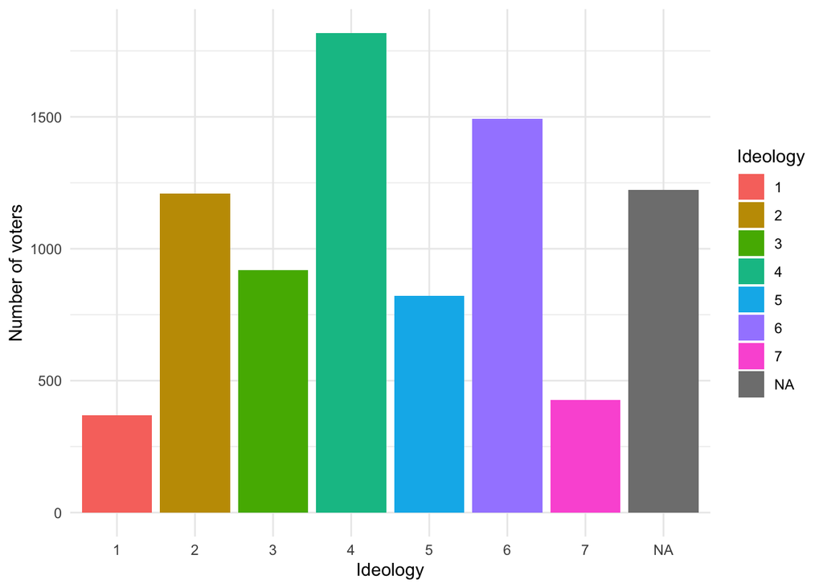

```r
ggplot(anes, aes(x = factor(ideology), fill = factor(ideology))) +
  geom_bar() +

  labs(x = "Ideology", y = "Number of voters", fill = "Ideology") +
  theme_minimal()
```

- 4 is the most common ideology.
- The two smallest bars are at the extreme ends of the plot, so most respondents aren’t at ideological extremes and tend to be moderate.
- A considerable number of respondents didn’t disclose their ideology, which should be considered when interpreting the visualization.

# Exercise 4

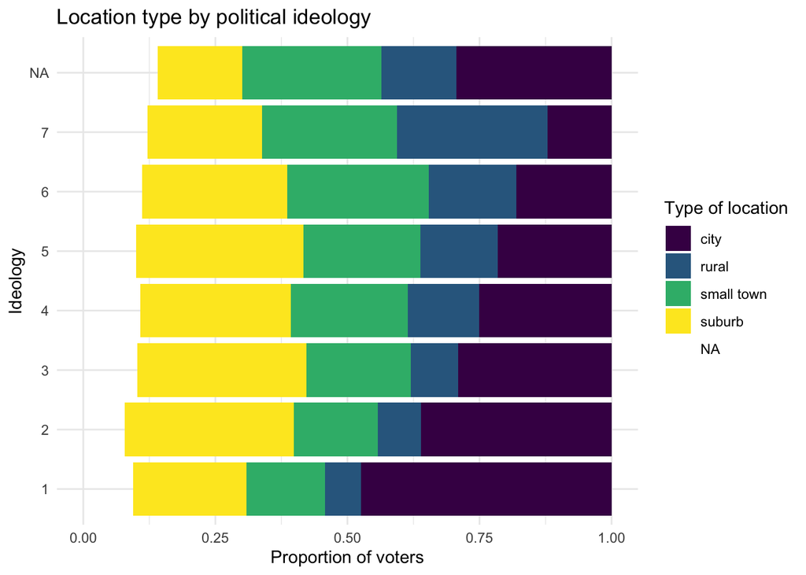

```r
ggplot(anes, aes(y = factor(ideology), fill = urbanrural)) +
  geom_bar(position = "fill") +
  scale_fill_viridis_d() +
  labs(x = "Proportion of voters",
       y = "Ideology",
       fill = "Type of location",
       title = "Location type by political ideology") +
  theme_minimal()
```

- Reading across the bars: more liberal respondents lean toward city/suburb, while more conservative respondents carry a larger share of small town/rural. Location type shifts as you move along the ideology scale.
- Proportions make it easier to compare the internal composition of each ideology group. If we relied on counts, a populous location type would swallow the smaller ones and the composition would be hard to compare across ideologies.
- The proportion of N/A across the ideology bars is fairly consistent and doesn’t vary substantially by ideology.

# Exercise 5

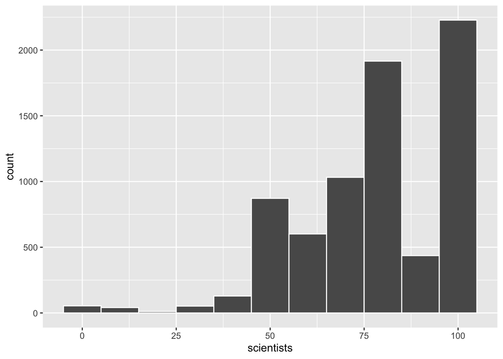

```r
ggplot(anes, aes(x = scientists)) +
  geom_histogram(color = "white", binwidth = 10)
```

# Exercise 6

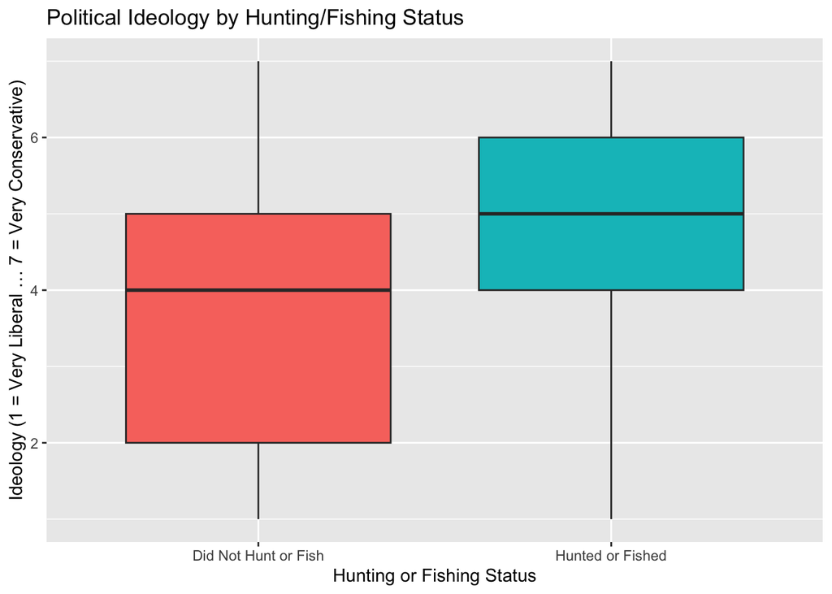

```r
anes |>
  drop_na(hunt_fish, ideology) |>
  mutate(
    hunted_fished = if_else(
      hunt_fish == 0,
      "Did Not Hunt or Fish",
      "Hunted or Fished"
    )
  ) |>
  ggplot(aes(x = hunted_fished, y = ideology, fill = hunted_fished)) +
  geom_boxplot() +
  labs(
    title = "Political Ideology by Hunting/Fishing Status",
    x = "Hunting or Fishing Status",
    y = "Ideology (1 = Very Liberal … 7 = Very Conservative)",
    fill = NULL
  ) +
  theme(legend.position = "none")
```

- Yes. The hunt/fish group sits higher on the scale and carries more mass in the conservative (5–7) range, while non-hunters cluster closer to the moderate middle.

# Exercise 7

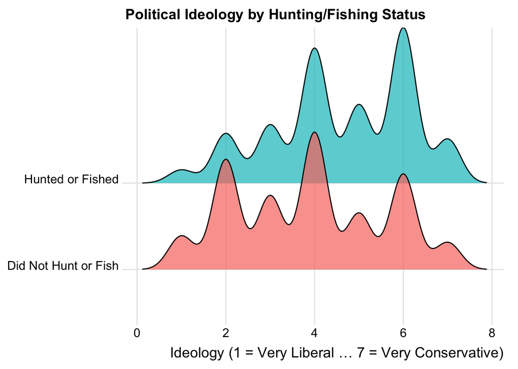

```r
anes |>
  drop_na(hunt_fish, ideology) |>
  mutate(
    hunted_fished = if_else(hunt_fish == 0, "Did Not Hunt or Fish", "Hunted or Fished")
  ) |>
  ggplot(aes(x = ideology, y = hunted_fished, fill = hunted_fished)) +
  geom_density_ridges(alpha = 0.7) +
  labs(
    title = "Political Ideology by Hunting/Fishing Status",
    x = "Ideology (1 = Very Liberal … 7 = Very Conservative)",
    y = NULL,
    fill = NULL
  ) +
  theme_ridges() +
  theme(legend.position = "none")
```

# Exercise 8

- Both plots agree that hunters/fishers lean more conservative.
- The five-number summary about the data is easier to see on the box plot. If we’re trying to determine which median is higher, the box plot is easier to glean from.
- The ridge plots show the distributional shape far better than the compact boxes. So if we want to learn about the modality, skew and where most of the mass is, it’s the plot of choice.
- I think the ridge plot is better suited to glean a more nuanced understanding from. Not only does it communicate the information we could get from the boxplot, we also see a better visual of where most of the mass lives.
- ideology only takes 7 discrete values, so the ridge smooths them into continuous curves that imply gradations the scale doesn’t actually have.

# Exercise 9

- I don’t think so. Scatterplots are useful when the variables are continuous. Here education is discrete and scientists piles on round numbers, so the points collapse onto a grid.
- Education is ordinal, so the intervals aren’t necessarily equal. Treating the codes as evenly spaced assumes the gap between adjacent levels (e.g. one degree tier and the next) is the same everywhere. The line of best fit inherits the same problem.
- It only slightly makes sense. There’s a genuine positive slope (more education, more appreciation for scientists), but a straight line assumes a constant change per level on a scale that isn’t equally spaced, and scientists is bounded at 0/100 so the line mispredicts at the high end.
- I think a density ridge of scientists grouped by education level would do a better job

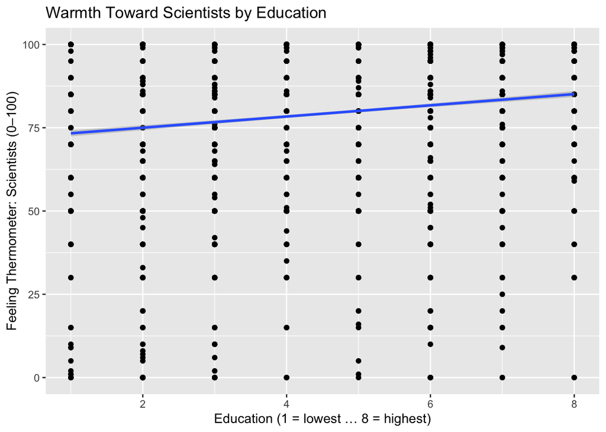

```r
anes |>
  drop_na(education, scientists) |>
  ggplot(aes(x = education, y = scientists)) +
  geom_point() +
  geom_smooth(method = "lm") +
  labs(
    title = "Warmth Toward Scientists by Education",
    x = "Education (1 = lowest … 8 = highest)",
    y = "Feeling Thermometer: Scientists (0–100)"
  )
```

# Exercise 10

- Is there a relationship between the type of place respondents reside and whether they’re into hunting/fishing?
- `hunt_fish` and `urbanrural`

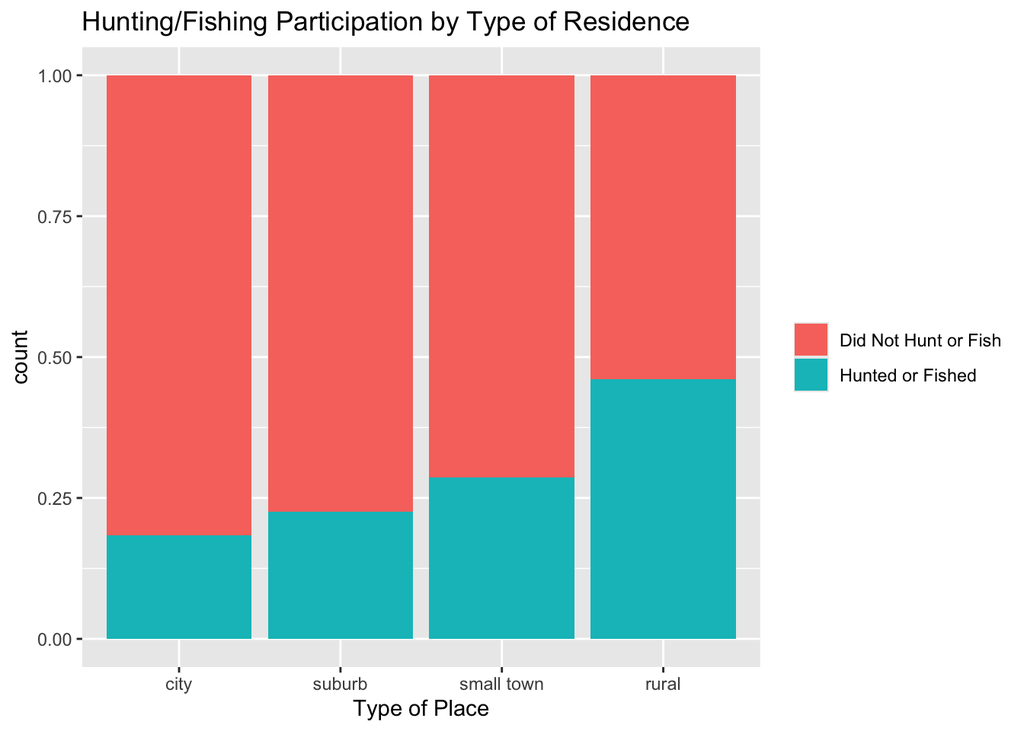

```r
anes |>
  drop_na(hunt_fish, urbanrural) |>
  mutate(
    hunted_fished = if_else(hunt_fish == 0, "Did Not Hunt or Fish", "Hunted or Fished"),

    urbanrural = factor(urbanrural, levels = c("city", "suburb", "small town", "rural"))
  ) |>
  ggplot(aes(x = urbanrural, fill = hunted_fished)) +
  geom_bar(position = "fill") +
  labs(
    title = "Hunting/Fishing Participation by Type of Residence",
    x = "Type of Place",
    fill = NULL
  )
```

- Both variables are categorical, and the number of respondents varies wildly across residence types, so I care about the *rate* of hunting/fishing within each type rather than raw counts. Scaling each bar to a proportion answers “of the people who live here, what fraction hunt or fish?”.
- Unsurprisingly, the closer a person is to the city, the less likely they are to engage in hunting or fishing.

# Exercise 11

A pattern across these analyses is one of degree: hunters and fishers lean somewhat more conservative and skew rural, while warmth toward scientists climbs modestly with education. Several limitations temper these findings. Every relationship shown is bivariate, so nothing holds confounders like rurality, age, or partisanship constant, and the results rest on unweighted data with missing values dropped. Because of this, these visualizations cannot support any causal claim, nor can they generalize reliably to the national electorate. I would want multivariate models, ANES survey weights, and longitudinal data to test whether these associations persist over time.